# Risk Factor Analysis

## Outcome Variable

**Outcome Variable:** sstunted

## Predictor Variables

**Intervention Variable:** hdlvry

**Adjustment Set:**

- arm
- sex
- W_mage
- meducyrs
- W_nrooms
- brthmon
- W_parity
- impsan
- delta_W_mage
- delta_meducyrs
- delta_W_nrooms
- delta_brthmon
- delta_W_parity
- delta_impsan

## Stratifying Variables

The analysis was stratified on these variable(s):

- agecat
- studyid
- country

## Data Summary

| agecat | studyid | country | hdlvry | sstunted | n_cell | n |
| --- | --- | --- | --- | --- | --- | --- |
| Birth | ki1000108-CMC-V-BCS-2002 | INDIA | 0 | 0 | 87 | 90 |
| Birth | ki1000108-CMC-V-BCS-2002 | INDIA | 0 | 1 | 3 | 90 |
| Birth | ki1000108-CMC-V-BCS-2002 | INDIA | 1 | 0 | 0 | 90 |
| Birth | ki1000108-CMC-V-BCS-2002 | INDIA | 1 | 1 | 0 | 90 |
| Birth | ki1000108-IRC | INDIA | 0 | 0 | 365 | 388 |
| Birth | ki1000108-IRC | INDIA | 0 | 1 | 16 | 388 |
| Birth | ki1000108-IRC | INDIA | 1 | 0 | 7 | 388 |
| Birth | ki1000108-IRC | INDIA | 1 | 1 | 0 | 388 |
| Birth | ki1000109-EE | PAKISTAN | 0 | 0 | 2 | 2 |
| Birth | ki1000109-EE | PAKISTAN | 0 | 1 | 0 | 2 |
| Birth | ki1000109-EE | PAKISTAN | 1 | 0 | 0 | 2 |
| Birth | ki1000109-EE | PAKISTAN | 1 | 1 | 0 | 2 |
| Birth | ki1000304b-SAS-CompFeed | INDIA | 0 | 0 | 10 | 180 |
| Birth | ki1000304b-SAS-CompFeed | INDIA | 0 | 1 | 1 | 180 |
| Birth | ki1000304b-SAS-CompFeed | INDIA | 1 | 0 | 160 | 180 |
| Birth | ki1000304b-SAS-CompFeed | INDIA | 1 | 1 | 9 | 180 |
| Birth | ki1017093c-NIH-Crypto | BANGLADESH | 0 | 0 | 21 | 27 |
| Birth | ki1017093c-NIH-Crypto | BANGLADESH | 0 | 1 | 1 | 27 |
| Birth | ki1017093c-NIH-Crypto | BANGLADESH | 1 | 0 | 5 | 27 |
| Birth | ki1017093c-NIH-Crypto | BANGLADESH | 1 | 1 | 0 | 27 |
| Birth | ki1135781-COHORTS | INDIA | 0 | 0 | 2855 | 4694 |
| Birth | ki1135781-COHORTS | INDIA | 0 | 1 | 83 | 4694 |
| Birth | ki1135781-COHORTS | INDIA | 1 | 0 | 1702 | 4694 |
| Birth | ki1135781-COHORTS | INDIA | 1 | 1 | 54 | 4694 |
| Birth | kiGH5241-JiVitA-3 | BANGLADESH | 0 | 0 | 11 | 300 |
| Birth | kiGH5241-JiVitA-3 | BANGLADESH | 0 | 1 | 0 | 300 |
| Birth | kiGH5241-JiVitA-3 | BANGLADESH | 1 | 0 | 274 | 300 |
| Birth | kiGH5241-JiVitA-3 | BANGLADESH | 1 | 1 | 15 | 300 |
| Birth | kiGH5241-JiVitA-4 | BANGLADESH | 0 | 0 | 45 | 820 |
| Birth | kiGH5241-JiVitA-4 | BANGLADESH | 0 | 1 | 2 | 820 |

[output cut: 86 more lines]

The following strata were considered:

- agecat: 24 months, studyid: ki1000108-CMC-V-BCS-2002, country: INDIA
- agecat: 24 months, studyid: ki1000108-IRC, country: INDIA
- agecat: 24 months, studyid: ki1017093b-PROVIDE, country: BANGLADESH
- agecat: 24 months, studyid: ki1017093c-NIH-Crypto, country: BANGLADESH
- agecat: 24 months, studyid: ki1066203-TanzaniaChild2, country: TANZANIA, UNITED REPUBLIC OF
- agecat: 24 months, studyid: ki1113344-GMS-Nepal, country: NEPAL
- agecat: 24 months, studyid: ki1135781-COHORTS, country: INDIA
- agecat: 24 months, studyid: kiGH5241-JiVitA-3, country: BANGLADESH
- agecat: 24 months, studyid: kiGH5241-JiVitA-4, country: BANGLADESH
- agecat: 6 months, studyid: ki1000108-CMC-V-BCS-2002, country: INDIA
- agecat: 6 months, studyid: ki1000108-IRC, country: INDIA
- agecat: 6 months, studyid: ki1000109-EE, country: PAKISTAN
- agecat: 6 months, studyid: ki1000304b-SAS-CompFeed, country: INDIA
- agecat: 6 months, studyid: ki1000304b-SAS-FoodSuppl, country: INDIA
- agecat: 6 months, studyid: ki1017093b-PROVIDE, country: BANGLADESH
- agecat: 6 months, studyid: ki1017093c-NIH-Crypto, country: BANGLADESH
- agecat: 6 months, studyid: ki1066203-TanzaniaChild2, country: TANZANIA, UNITED REPUBLIC OF
- agecat: 6 months, studyid: ki1113344-GMS-Nepal, country: NEPAL
- agecat: 6 months, studyid: ki1135781-COHORTS, country: INDIA
- agecat: 6 months, studyid: kiGH5241-JiVitA-3, country: BANGLADESH
- agecat: 6 months, studyid: kiGH5241-JiVitA-4, country: BANGLADESH
- agecat: Birth, studyid: ki1000108-CMC-V-BCS-2002, country: INDIA
- agecat: Birth, studyid: ki1000108-IRC, country: INDIA
- agecat: Birth, studyid: ki1000109-EE, country: PAKISTAN
- agecat: Birth, studyid: ki1000304b-SAS-CompFeed, country: INDIA
- agecat: Birth, studyid: ki1017093c-NIH-Crypto, country: BANGLADESH
- agecat: Birth, studyid: ki1135781-COHORTS, country: INDIA
- agecat: Birth, studyid: kiGH5241-JiVitA-3, country: BANGLADESH
- agecat: Birth, studyid: kiGH5241-JiVitA-4, country: BANGLADESH

### Dropped Strata

Some strata were dropped due to rare outcomes:

- agecat: Birth, studyid: ki1000108-CMC-V-BCS-2002, country: INDIA
- agecat: Birth, studyid: ki1000108-IRC, country: INDIA
- agecat: Birth, studyid: ki1000109-EE, country: PAKISTAN
- agecat: Birth, studyid: ki1000304b-SAS-CompFeed, country: INDIA
- agecat: Birth, studyid: ki1017093c-NIH-Crypto, country: BANGLADESH
- agecat: Birth, studyid: kiGH5241-JiVitA-3, country: BANGLADESH
- agecat: Birth, studyid: kiGH5241-JiVitA-4, country: BANGLADESH
- agecat: 6 months, studyid: ki1000108-CMC-V-BCS-2002, country: INDIA
- agecat: 6 months, studyid: ki1000108-IRC, country: INDIA
- agecat: 6 months, studyid: ki1017093c-NIH-Crypto, country: BANGLADESH
- agecat: 6 months, studyid: ki1066203-TanzaniaChild2, country: TANZANIA, UNITED REPUBLIC OF
- agecat: 6 months, studyid: ki1113344-GMS-Nepal, country: NEPAL
- agecat: 6 months, studyid: kiGH5241-JiVitA-3, country: BANGLADESH
- agecat: 24 months, studyid: ki1000108-CMC-V-BCS-2002, country: INDIA
- agecat: 24 months, studyid: ki1000108-IRC, country: INDIA
- agecat: 24 months, studyid: ki1066203-TanzaniaChild2, country: TANZANIA, UNITED REPUBLIC OF
- agecat: 24 months, studyid: kiGH5241-JiVitA-3, country: BANGLADESH

## Methods Detail

We’re interested in the causal parameters $E[Y_a]$ for all values of $a \in \mathcal{A}$. These parameters represent the mean outcome if, possibly contrary to fact, we intervened to set all units to have $A=a$. Under the randomization and positivity assumptions, these are identified by the statistical parameters $\psi_a=E_W[E_{Y|A,W}(Y|A=a,W)]$. In addition, we’re interested in the mean of $Y$, $E[Y]$ under no intervention (the observed mean). We will estimate these parameters by using SuperLearner to fit the relevant likelihood factors – $E_{Y|A,W}(Y|A=a,W)$ and $p(A=a|W)$, and then updating our likelihood fit using a joint TMLE.

For unadjusted analyses ($W=\{\}$), initial likelihoods were estimated using Lrnr_glm to estimate the simple $E(Y|A)$ and Lrnr_mean to estimate $p(A)$. For adjusted analyses, a small library containing Lrnr_glmnet, Lrnr_xgboost, and Lrnr_mean was used.

Having estimated these parameters, we will then use the delta method to estimate relative risks and attributable risks relative to a prespecified baseline level of $A$.

# Results Detail

## Results Plots

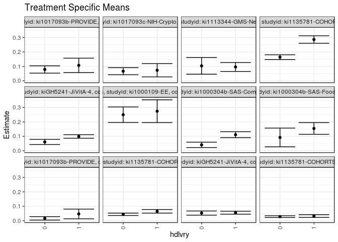

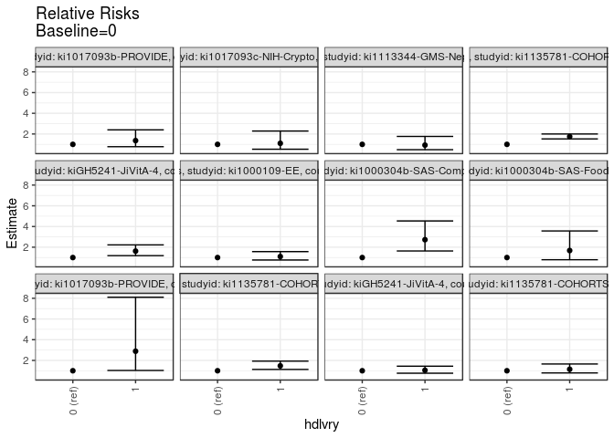

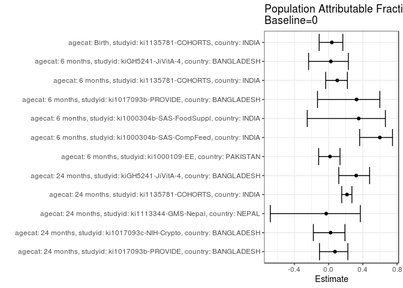

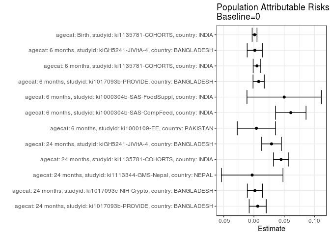

## Results Table

### Parameter: TSM

| agecat | studyid | country | intervention_level | baseline_level | estimate | ci_lower | ci_upper |
| --- | --- | --- | --- | --- | --- | --- | --- |
| Birth | ki1135781-COHORTS | INDIA | 0 | NA | 0.0280900 | 0.0219197 | 0.0342602 |
| Birth | ki1135781-COHORTS | INDIA | 1 | NA | 0.0321032 | 0.0225811 | 0.0416253 |
| 6 months | ki1000109-EE | PAKISTAN | 0 | NA | 0.2499492 | 0.1959550 | 0.3039435 |
| 6 months | ki1000109-EE | PAKISTAN | 1 | NA | 0.2742696 | 0.1952323 | 0.3533068 |
| 6 months | ki1000304b-SAS-CompFeed | INDIA | 0 | NA | 0.0408163 | 0.0221750 | 0.0594577 |
| 6 months | ki1000304b-SAS-CompFeed | INDIA | 1 | NA | 0.1112288 | 0.0906768 | 0.1317809 |
| 6 months | ki1000304b-SAS-FoodSuppl | INDIA | 0 | NA | 0.0921053 | 0.0270064 | 0.1572041 |
| 6 months | ki1000304b-SAS-FoodSuppl | INDIA | 1 | NA | 0.1546053 | 0.1139117 | 0.1952988 |
| 6 months | ki1017093b-PROVIDE | BANGLADESH | 0 | NA | 0.0161663 | 0.0042773 | 0.0280552 |
| 6 months | ki1017093b-PROVIDE | BANGLADESH | 1 | NA | 0.0466667 | 0.0128834 | 0.0804499 |
| 6 months | ki1135781-COHORTS | INDIA | 0 | NA | 0.0441590 | 0.0357417 | 0.0525764 |
| 6 months | ki1135781-COHORTS | INDIA | 1 | NA | 0.0651337 | 0.0527710 | 0.0774965 |
| 6 months | kiGH5241-JiVitA-4 | BANGLADESH | 0 | NA | 0.0528435 | 0.0385121 | 0.0671748 |
| 6 months | kiGH5241-JiVitA-4 | BANGLADESH | 1 | NA | 0.0553389 | 0.0450799 | 0.0655978 |
| 24 months | ki1017093b-PROVIDE | BANGLADESH | 0 | NA | 0.0786655 | 0.0532914 | 0.1040395 |
| 24 months | ki1017093b-PROVIDE | BANGLADESH | 1 | NA | 0.1072027 | 0.0573850 | 0.1570205 |
| 24 months | ki1017093c-NIH-Crypto | BANGLADESH | 0 | NA | 0.0664962 | 0.0417767 | 0.0912156 |
| 24 months | ki1017093c-NIH-Crypto | BANGLADESH | 1 | NA | 0.0731707 | 0.0271040 | 0.1192374 |
| 24 months | ki1113344-GMS-Nepal | NEPAL | 0 | NA | 0.1035317 | 0.0456708 | 0.1613926 |
| 24 months | ki1113344-GMS-Nepal | NEPAL | 1 | NA | 0.0958487 | 0.0648776 | 0.1268198 |
| 24 months | ki1135781-COHORTS | INDIA | 0 | NA | 0.1638769 | 0.1471538 | 0.1805999 |
| 24 months | ki1135781-COHORTS | INDIA | 1 | NA | 0.2866027 | 0.2607163 | 0.3124891 |
| 24 months | kiGH5241-JiVitA-4 | BANGLADESH | 0 | NA | 0.0610559 | 0.0432264 | 0.0788854 |
| 24 months | kiGH5241-JiVitA-4 | BANGLADESH | 1 | NA | 0.0991144 | 0.0868584 | 0.1113703 |

### Parameter: E(Y)

| agecat | studyid | country | intervention_level | baseline_level | estimate | ci_lower | ci_upper |
| --- | --- | --- | --- | --- | --- | --- | --- |
| Birth | ki1135781-COHORTS | INDIA | NA | NA | 0.0291862 | 0.0243703 | 0.0340021 |
| 6 months | ki1000109-EE | PAKISTAN | NA | NA | 0.2540541 | 0.2096368 | 0.2984713 |
| 6 months | ki1000304b-SAS-CompFeed | INDIA | NA | NA | 0.1017415 | 0.0806841 | 0.1227990 |
| 6 months | ki1000304b-SAS-FoodSuppl | INDIA | NA | NA | 0.1421053 | 0.1069532 | 0.1772573 |
| 6 months | ki1017093b-PROVIDE | BANGLADESH | NA | NA | 0.0240137 | 0.0115761 | 0.0364514 |
| 6 months | ki1135781-COHORTS | INDIA | NA | NA | 0.0491594 | 0.0429771 | 0.0553417 |
| 6 months | kiGH5241-JiVitA-4 | BANGLADESH | NA | NA | 0.0542348 | 0.0458525 | 0.0626170 |
| 24 months | ki1017093b-PROVIDE | BANGLADESH | NA | NA | 0.0849220 | 0.0621566 | 0.1076874 |
| 24 months | ki1017093c-NIH-Crypto | BANGLADESH | NA | NA | 0.0680934 | 0.0462948 | 0.0898920 |
| 24 months | ki1113344-GMS-Nepal | NEPAL | NA | NA | 0.1006424 | 0.0733267 | 0.1279581 |
| 24 months | ki1135781-COHORTS | INDIA | NA | NA | 0.2087665 | 0.1954120 | 0.2221210 |
| 24 months | kiGH5241-JiVitA-4 | BANGLADESH | NA | NA | 0.0901373 | 0.0799465 | 0.1003281 |

### Parameter: RR

| agecat | studyid | country | intervention_level | baseline_level | estimate | ci_lower | ci_upper |
| --- | --- | --- | --- | --- | --- | --- | --- |
| Birth | ki1135781-COHORTS | INDIA | 0 | 0 | 1.0000000 | 1.0000000 | 1.000000 |
| Birth | ki1135781-COHORTS | INDIA | 1 | 0 | 1.1428720 | 0.7901295 | 1.653091 |
| 6 months | ki1000109-EE | PAKISTAN | 0 | 0 | 1.0000000 | 1.0000000 | 1.000000 |
| 6 months | ki1000109-EE | PAKISTAN | 1 | 0 | 1.0973010 | 0.7643412 | 1.575304 |
| 6 months | ki1000304b-SAS-CompFeed | INDIA | 0 | 0 | 1.0000000 | 1.0000000 | 1.000000 |
| 6 months | ki1000304b-SAS-CompFeed | INDIA | 1 | 0 | 2.7251056 | 1.6370778 | 4.536254 |
| 6 months | ki1000304b-SAS-FoodSuppl | INDIA | 0 | 0 | 1.0000000 | 1.0000000 | 1.000000 |
| 6 months | ki1000304b-SAS-FoodSuppl | INDIA | 1 | 0 | 1.6785713 | 0.7895723 | 3.568516 |
| 6 months | ki1017093b-PROVIDE | BANGLADESH | 0 | 0 | 1.0000000 | 1.0000000 | 1.000000 |
| 6 months | ki1017093b-PROVIDE | BANGLADESH | 1 | 0 | 2.8866667 | 1.0285604 | 8.101463 |
| 6 months | ki1135781-COHORTS | INDIA | 0 | 0 | 1.0000000 | 1.0000000 | 1.000000 |
| 6 months | ki1135781-COHORTS | INDIA | 1 | 0 | 1.4749806 | 1.1276808 | 1.929241 |
| 6 months | kiGH5241-JiVitA-4 | BANGLADESH | 0 | 0 | 1.0000000 | 1.0000000 | 1.000000 |
| 6 months | kiGH5241-JiVitA-4 | BANGLADESH | 1 | 0 | 1.0472227 | 0.7621124 | 1.438994 |
| 24 months | ki1017093b-PROVIDE | BANGLADESH | 0 | 0 | 1.0000000 | 1.0000000 | 1.000000 |
| 24 months | ki1017093b-PROVIDE | BANGLADESH | 1 | 0 | 1.3627674 | 0.7731252 | 2.402114 |
| 24 months | ki1017093c-NIH-Crypto | BANGLADESH | 0 | 0 | 1.0000000 | 1.0000000 | 1.000000 |
| 24 months | ki1017093c-NIH-Crypto | BANGLADESH | 1 | 0 | 1.1003752 | 0.5296782 | 2.285965 |
| 24 months | ki1113344-GMS-Nepal | NEPAL | 0 | 0 | 1.0000000 | 1.0000000 | 1.000000 |
| 24 months | ki1113344-GMS-Nepal | NEPAL | 1 | 0 | 0.9257906 | 0.4849281 | 1.767454 |
| 24 months | ki1135781-COHORTS | INDIA | 0 | 0 | 1.0000000 | 1.0000000 | 1.000000 |
| 24 months | ki1135781-COHORTS | INDIA | 1 | 0 | 1.7488907 | 1.5279836 | 2.001735 |
| 24 months | kiGH5241-JiVitA-4 | BANGLADESH | 0 | 0 | 1.0000000 | 1.0000000 | 1.000000 |
| 24 months | kiGH5241-JiVitA-4 | BANGLADESH | 1 | 0 | 1.6233381 | 1.1851426 | 2.223552 |

### Parameter: PAR

| agecat | studyid | country | intervention_level | baseline_level | estimate | ci_lower | ci_upper |
| --- | --- | --- | --- | --- | --- | --- | --- |
| Birth | ki1135781-COHORTS | INDIA | 0 | NA | 0.0010962 | -0.0029281 | 0.0051206 |
| 6 months | ki1000109-EE | PAKISTAN | 0 | NA | 0.0041048 | -0.0275213 | 0.0357309 |
| 6 months | ki1000304b-SAS-CompFeed | INDIA | 0 | NA | 0.0609252 | 0.0357423 | 0.0861081 |
| 6 months | ki1000304b-SAS-FoodSuppl | INDIA | 0 | NA | 0.0500000 | -0.0114686 | 0.1114686 |
| 6 months | ki1017093b-PROVIDE | BANGLADESH | 0 | NA | 0.0078474 | -0.0014306 | 0.0171255 |
| 6 months | ki1135781-COHORTS | INDIA | 0 | NA | 0.0050004 | -0.0012594 | 0.0112601 |
| 6 months | kiGH5241-JiVitA-4 | BANGLADESH | 0 | NA | 0.0013913 | -0.0111250 | 0.0139077 |
| 24 months | ki1017093b-PROVIDE | BANGLADESH | 0 | NA | 0.0062565 | -0.0078421 | 0.0203552 |
| 24 months | ki1017093c-NIH-Crypto | BANGLADESH | 0 | NA | 0.0015972 | -0.0109158 | 0.0141102 |
| 24 months | ki1113344-GMS-Nepal | NEPAL | 0 | NA | -0.0028893 | -0.0538050 | 0.0480264 |
| 24 months | ki1135781-COHORTS | INDIA | 0 | NA | 0.0448896 | 0.0322553 | 0.0575239 |
| 24 months | kiGH5241-JiVitA-4 | BANGLADESH | 0 | NA | 0.0290814 | 0.0128381 | 0.0453248 |

### Parameter: PAF

| agecat | studyid | country | intervention_level | baseline_level | estimate | ci_lower | ci_upper |
| --- | --- | --- | --- | --- | --- | --- | --- |
| Birth | ki1135781-COHORTS | INDIA | 0 | NA | 0.0375600 | -0.1106090 | 0.1659613 |
| 6 months | ki1000109-EE | PAKISTAN | 0 | NA | 0.0161572 | -0.1165175 | 0.1330663 |
| 6 months | ki1000304b-SAS-CompFeed | INDIA | 0 | NA | 0.5988233 | 0.3630716 | 0.7473142 |
| 6 months | ki1000304b-SAS-FoodSuppl | INDIA | 0 | NA | 0.3518518 | -0.2498734 | 0.6638891 |
| 6 months | ki1017093b-PROVIDE | BANGLADESH | 0 | NA | 0.3267898 | -0.1300269 | 0.5989370 |
| 6 months | ki1135781-COHORTS | INDIA | 0 | NA | 0.1017173 | -0.0345775 | 0.2200568 |
| 6 months | kiGH5241-JiVitA-4 | BANGLADESH | 0 | NA | 0.0256535 | -0.2342777 | 0.2308448 |
| 24 months | ki1017093b-PROVIDE | BANGLADESH | 0 | NA | 0.0736740 | -0.1068600 | 0.2247620 |
| 24 months | ki1017093c-NIH-Crypto | BANGLADESH | 0 | NA | 0.0234563 | -0.1785745 | 0.1908551 |
| 24 months | ki1113344-GMS-Nepal | NEPAL | 0 | NA | -0.0287086 | -0.6822385 | 0.3709326 |
| 24 months | ki1135781-COHORTS | INDIA | 0 | NA | 0.2150232 | 0.1529947 | 0.2725092 |
| 24 months | kiGH5241-JiVitA-4 | BANGLADESH | 0 | NA | 0.3226347 | 0.1185340 | 0.4794766 |